# Statistics in Action - case study 1

Sebastien Moeller

```r
if (!require("pacman")) install.packages("pacman")
```

```r
pacman::p_load(equivalence, tidyverse, ggplot2, dplyr, plyr, pwr)
```

# Introduction

The dataset dataMON810_2018.csv consists of several measurements made during a subchronic toxicity study concerning the MON810 maize.

Biochemical parameters reflecting most physiological functions were measured two times (week 5 and 14), in particular through serum and urine chemistry, and hematology. Organ weights were measured at week 14.

The main objective of this study is to evaluate possible GMO effects on these parameters.

# Single comparison

#### **(Q1)**

We consider the variable “CALCIUM”.

```r
data <- read.csv('dataMON810_2018.csv')
```

##### a. Test if the mean level of calcium for period 2 is the same for males and females. **Hint:** plot first the data and justify the test(s) to use.

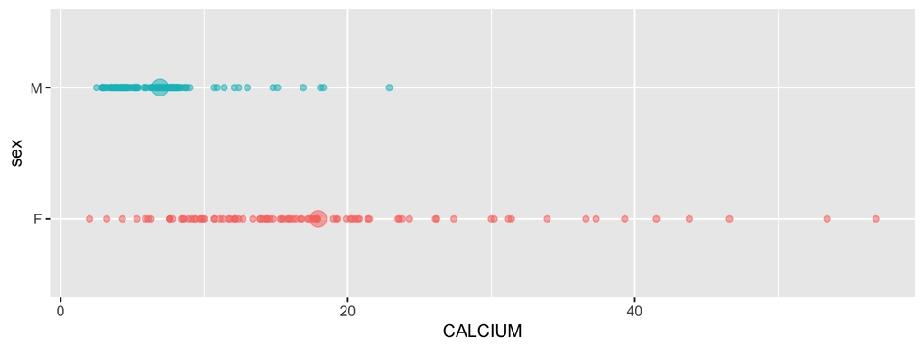

```r
# Filter the data was want and remove NA from variable
calciumA <- data %>% filter(period == 2) %>% select(CALCIUM, sex) %>% na.omit
# Calculate the sample means
calciumAMean <- aggregate(calciumA$CALCIUM  ~ calciumA$sex, FUN = 'mean')
colnames(calciumAMean) <- c('sex', 'CALCIUM')

# Plot the data
ggplot() +
  geom_point(data = calciumA, aes(x = CALCIUM, y = sex, colour = sex, alpha = 0.5), show.legend = FALSE) +
  geom_point(data = calciumAMean, aes(x = CALCIUM, y = sex, color = sex, size = 4, alpha = 0.5), show.legend = FALSE)
```

```r
# Let's take a look at the means
calciumAMean
```

```
##   sex   CALCIUM
## 1   F 17.943333
## 2   M  6.930928
```

The hypotheses we are testing are as follow:
$$H_0:\mu_{x} = \mu_{y} \space\text{ versus }\space H_1:\mu_{x} \neq\mu_{y}$$

##### Let us look at the distribution of the observations

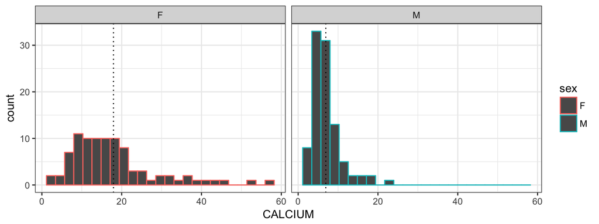

```r
calciumA <- ddply(calciumA, 'sex', transform, mean = mean(CALCIUM))

ggplot(data = calciumA, aes(x = CALCIUM, color = sex)) + geom_histogram(bins = 25) +
  geom_vline(aes(xintercept = mean), linetype = 3) +
  facet_grid(~sex) + theme_bw()
```

The histograms seem to reveal a distribution not too far from normal. This allows us to apply the student t-test to compare the means as it assumes normallity.

##### Assuming equal variances

We can use the function `t.test`. Let $x$ and $y$ denote $males$ and $females$ respectively.

We run our first test assuming equal variances $(\sigma^2_x = \sigma^2_y)$. We select a 5% significance level and run the test.

```r
alpha <- 0.05
t.test((calciumA %>% filter(sex == 'M'))$CALCIUM, (calciumA %>% filter(sex == 'F'))$CALCIUM, conf.level = 1 - alpha, var.equal = TRUE)
```

```
##
##  Two Sample t-test
##
## data:  (calciumA %>% filter(sex == "M"))$CALCIUM and (calciumA %>% filter(sex == "F"))$CALCIUM
## t = -9.4633, df = 185, p-value < 2.2e-16
## alternative hypothesis: true difference in means is not equal to 0
## 95 percent confidence interval:
##  -13.308233  -8.716578
## sample estimates:
## mean of x mean of y
##  6.930928 17.943333
```

Under the assumption that the two sexes have equal variances, we find a low `p-value < 2.2e-16` and thus **reject the null hypothesis** that $\mu_x = \mu_y$.

##### F-test for equal variances

As stated, the previous t-test assumed that the two populations have equal variances. It is unreasonable to make this assumption without an additional test. An F-test is used to test if the variances of two populations are equal. We will perform a two tailed test to see if our previous assumption was valid or not.

For the F-test, our hypotheses are as follow: $H_0: \sigma_x = \sigma_y \space\text{versus}\space H_1:\sigma_x \neq \sigma_y$

```r
test <- var.test((calciumA %>% filter(sex == 'M'))$CALCIUM, (calciumA %>% filter(sex == 'F'))$CALCIUM, conf.level = 1 - alpha, alternative = 'two.sided')
test
```

```
##
##  F test to compare two variances
##
## data:  (calciumA %>% filter(sex == "M"))$CALCIUM and (calciumA %>% filter(sex == "F"))$CALCIUM
## F = 0.11291, num df = 96, denom df = 89, p-value < 2.2e-16
## alternative hypothesis: true ratio of variances is not equal to 1
## 95 percent confidence interval:
##  0.07478163 0.16992670
## sample estimates:
## ratio of variances
##           0.112909
```

```r
# Do we reject the null hypothesis?
test$p.val < 0.05
```

```
## [1] TRUE
```

Our intuition was correct, the true ratio of variances $\frac{\sigma_x}{\sigma_y} \neq 1$. Thus we **reject the null hypothesis**.

##### Assuming different variances

Assuming equal variances between the two groups has been disputed.

```r
aggregate(calciumA$CALCIUM  ~ calciumA$sex, FUN = 'sd')
```

```
##   calciumA$sex calciumA$CALCIUM
## 1            F        10.823363
## 2            M         3.636859
```

```r
dim(calciumA[calciumA$sex == 'F',])[1]
```

```
## [1] 90
```

```r
dim(calciumA[calciumA$sex == 'M',])[1]
```

```
## [1] 97
```

The sample data of size 90 for females and 97 for males have very different standard deviations. It is therefore important to run the t-test without the assumption of equal variances.

```r
t.test((calciumA %>% filter(sex == 'M'))$CALCIUM, (calciumA %>% filter(sex == 'F'))$CALCIUM, conf.level = 1 - alpha, var.equal = FALSE)
```

```
##
##  Welch Two Sample t-test
##
## data:  (calciumA %>% filter(sex == "M"))$CALCIUM and (calciumA %>% filter(sex == "F"))$CALCIUM
## t = -9.1835, df = 107.53, p-value = 3.455e-15
## alternative hypothesis: true difference in means is not equal to 0
## 95 percent confidence interval:
##  -13.389455  -8.635356
## sample estimates:
## mean of x mean of y
##  6.930928 17.943333
```

Our new t-test also **rejects the null hypothesis** that the two groups share the same mean displaying a `p-value = 3.455e-15`.

##### Conclusion

We can safely conclude that the two sexes do indeed have different means by the means of a t-test without equal variances.

##### b. Test for the males if the mean level of calcium is the same for period 1 and period 2.

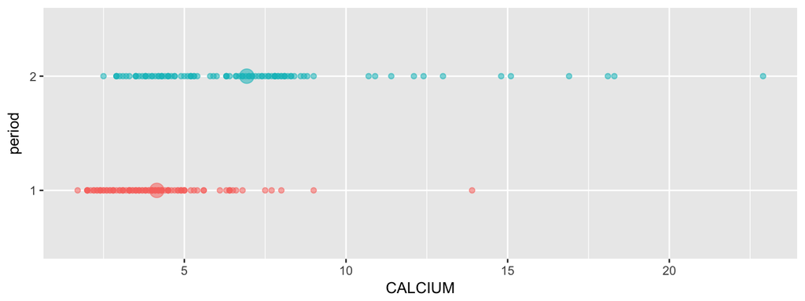

```r
# Filter the data was want and remove NA from variable
calciumB <- data %>% filter(sex == 'M') %>% select(period, CALCIUM) %>% na.omit
calciumB$period <- as.factor(calciumB$period)

calciumBMean <- aggregate(calciumB$CALCIUM  ~ calciumB$period, FUN = 'mean')
colnames(calciumBMean) <- c('period', 'CALCIUM')

# Plot the data
ggplot() +
  geom_point(data = calciumB, aes(x = CALCIUM, y = period, colour = period, alpha = 0.5), show.legend = FALSE) +
  geom_point(data = calciumBMean, aes(x = CALCIUM, y = period, color = period, size = 4, alpha = 0.5), show.legend = FALSE)
```

```r
# Let's take a look at the means
calciumBMean
```

```
##   period  CALCIUM
## 1      1 4.148980
## 2      2 6.930928
```

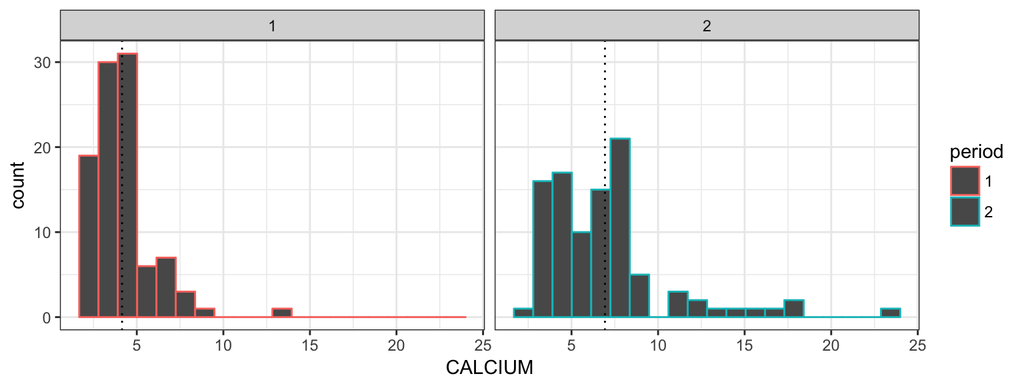

```r
calciumB <- ddply(calciumB, 'period', transform, mean = mean(CALCIUM))

ggplot(data = calciumB, aes(x = CALCIUM, color = period)) + geom_histogram(bins = 20) +
  geom_vline(aes(xintercept = mean), linetype = 3) +
  facet_grid(~period) + theme_bw()
```

As with the previous question, the data does seem to follow a normal distribution although it could be argued otherwise. For now, we will run our tests on the data using the t-test. We will consider other options in the later sections.

##### F-test for equal variances

As stated, the previous t-test assumed that the two populations have equal variances. An F-test is used to test if the variances of two populations are equal. We will perform a two tailed test to see if our previous assumption was valid or incorrect.

For the F-test, our hypotheses are as follow: $H_0: \sigma_x = \sigma_y \space\text{versus}\space H_1:\sigma_x \neq \sigma_y$

```r
test <- var.test((calciumB %>% filter(period == 1))$CALCIUM, (calciumB %>% filter(period == 2))$CALCIUM, conf.level = 1 - alpha, alternative = 'two.sided')
test
```

```
##
##  F test to compare two variances
##
## data:  (calciumB %>% filter(period == 1))$CALCIUM and (calciumB %>% filter(period == 2))$CALCIUM
## F = 0.23542, num df = 97, denom df = 96, p-value = 9.271e-12
## alternative hypothesis: true ratio of variances is not equal to 1
## 95 percent confidence interval:
##  0.1575523 0.3516297
## sample estimates:
## ratio of variances
##          0.2354219
```

```r
# Do we reject the null hypothesis
test$p.val < 0.05
```

```
## [1] TRUE
```

Our intuition was correct, the true ratio of variances $\frac{\sigma_x}{\sigma_y} \neq 1$. Thus we **reject the null hypothesis**.

##### Assuming different variances

Assuming equal variances between the two groups has been disputed.

```r
aggregate(calciumB$CALCIUM  ~ calciumB$period, FUN = 'sd')
```

```
##   calciumB$period calciumB$CALCIUM
## 1               1         1.764615
## 2               2         3.636859
```

```r
dim(filter(calciumB, period == 1))[1]
```

```
## [1] 98
```

```r
dim(filter(calciumB, period == 2))[1]
```

```
## [1] 97
```

The sample data of size 98 for period 1, and 97 for period 2 have very different standard deviations. It is therefore important to run the t-test without the assumption of equal variances especially because we rejected the F-test’s null hypothesis.

```r
test <- t.test((calciumB %>% filter(period == 1))$CALCIUM, (calciumB %>% filter(period == 2))$CALCIUM, conf.level = 1 - alpha, var.equal = FALSE)
test
```

```
##
##  Welch Two Sample t-test
##
## data:  (calciumB %>% filter(period == 1))$CALCIUM and (calciumB %>% filter(period == 2))$CALCIUM
## t = -6.7846, df = 138.51, p-value = 3.113e-10
## alternative hypothesis: true difference in means is not equal to 0
## 95 percent confidence interval:
##  -3.592694 -1.971202
## sample estimates:
## mean of x mean of y
##  4.148980  6.930928
```

```r
# Do we reject the null hypothesis?
test$p.value < 0.05
```

```
## [1] TRUE
```

Our new t-test also **rejects the null hypothesis** that the two groups share the same mean displaying a `p-value = 3.113e-10`.

##### Conclusion

We can safely conclude that the male population between the two periods do indeed have different means.

##### c. Test for the males if the mean level of calcium for period 2 is the same for the control group and the MON810 group.

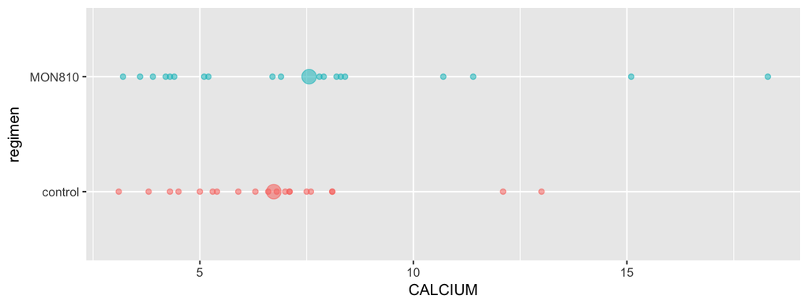

```r
# Filter the data was want and remove NA from variable
calciumC <- data %>% filter(sex == 'M') %>% filter(period == 2) %>% select(regimen, CALCIUM) %>% filter(regimen %in% c('MON810', 'control')) %>% na.omit
calciumC$regimen <- as.factor(calciumC$regimen)

calciumCMean <- aggregate(calciumC$CALCIUM  ~ calciumC$regimen, FUN = 'mean')
colnames(calciumCMean) <- c('regimen', 'CALCIUM')

# Plot the data
ggplot() +
  geom_point(data = calciumC, aes(x = CALCIUM, y = regimen, colour = regimen, alpha = 0.5), show.legend = FALSE) +
  geom_point(data = calciumCMean, aes(x = CALCIUM, y = regimen, color = regimen, size = 4, alpha = 0.5), show.legend = FALSE)
```

```r
# Let's take a look at the means
calciumCMean
```

```
##   regimen  CALCIUM
## 1 control 6.730000
## 2  MON810 7.557895
```

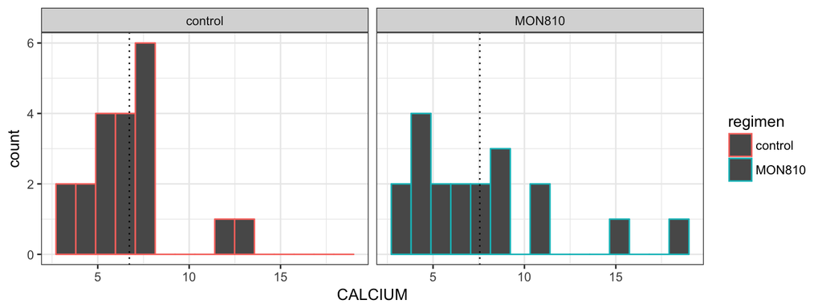

```r
calciumC <- ddply(calciumC, 'regimen', transform, mean = mean(CALCIUM))

ggplot(data = calciumC, aes(x = CALCIUM, color = regimen)) + geom_histogram(bins = 15) +
  geom_vline(aes(xintercept = mean), linetype = 3) +
  facet_grid(~regimen) + theme_bw()
```

```r
# Number of observations from the control group
dim(filter(calciumC, regimen == 'control'))[1]
```

```
## [1] 20
```

```r
# Number of observations frmo the MON810 group
dim(filter(calciumC, regimen == 'MON810'))[1]
```

```
## [1] 19
```

The histogram is a little worrying as the data seems unlikely to follow a normal distribution. As the sample size for the groups is 20 for control and 19 for MON810 which are rather low, it is harder to grasp the distribution via the histogram.

##### Wilcox Test

The advantage with Wilcoxon Signed Rank Test is that it neither depends on the form of the parent distribution nor on its parameters. It does not require any assumptions about the shape of the distribution.

For this reason, this test is often used as an alternative to the t-test whenever the population cannot be assumed to be normally distributed. Even if the normality assumption holds, it has been shown that the efficiency of this test compared to t-test is almost 95%.

```r
test <- wilcox.test((calciumC %>% filter(regimen == 'control'))$CALCIUM, (calciumC %>% filter(regimen == 'MON810'))$CALCIUM, alternative = 'two.sided', conf.level=1-0.05)
test
```

```
##
##  Wilcoxon rank sum test with continuity correction
##
## data:  (calciumC %>% filter(regimen == "control"))$CALCIUM and (calciumC %>% filter(regimen == "MON810"))$CALCIUM
## W = 175.5, p-value = 0.694
## alternative hypothesis: true location shift is not equal to 0
```

```r
# Do we reject the null hypothesis
test$p.value > 0.05
```

```
## [1] TRUE
```

Our new wilcox-test **rejects the alternate hypothesis** that the two groups do not share the same mean displaying a very significant `p-value = 0.694`.

Checking this resut with the t-test we used in the previous questions, we get the following result:

```r
t.test((calciumC %>% filter(regimen == 'control'))$CALCIUM, (calciumC %>% filter(regimen == 'MON810'))$CALCIUM, conf.level = 1 - alpha, var.equal = FALSE)
```

```
##
##  Welch Two Sample t-test
##
## data:  (calciumC %>% filter(regimen == "control"))$CALCIUM and (calciumC %>% filter(regimen == "MON810"))$CALCIUM
## t = -0.77136, df = 29.443, p-value = 0.4466
## alternative hypothesis: true difference in means is not equal to 0
## 95 percent confidence interval:
##  -3.021605  1.365815
## sample estimates:
## mean of x mean of y
##  6.730000  7.557895
```

Our t-test *also* **rejects the alternate hypothesis** that the two groups do not share the same mean displaying a very significant `p-value = 0.4466`.

##### Conclusion

We conclude that the two groups do not have significantly different means. We were able to discard our assumption for normality from the t-test by applying the wilcox test instead. This test appears to be more appropriate as our data has unusual distributions.

##### d. What is the probability to detect a difference of 1 sd (one standard deviation)

*i)* with only 10 animals per group? We can check this by running the code in the function pwr.t.test

```r
pwr.t.test(n = 10, d = 1, type = "two.sample", alternative = "two.sided", sig.level = alpha)[[4]]*100
```

```
## [1] 56.20066
```

So the probability of detecting 1 sd difference with only 10 animals per group is 56.20%

*ii)* with 20 animals? Next we try the same but change the sample size to 20 animals per group

```r
pwr.t.test(n = 20, d = 1, type = "two.sample", alternative = "two.sided", sig.level = alpha)[[4]]*100
```

```
## [1] 86.8953
```

The probability of detecting 1 sd difference with only 20 animals per group is 86.90%

*iii)* How can we ensure to detect such difference with a probability of 80%? For this we fill in the power function and set

```r
pwr.t.test(power = 0.8, d = 1, sig.level = alpha)
```

```
##
##      Two-sample t test power calculation
##
##               n = 16.71472
##               d = 1
##       sig.level = 0.05
##           power = 0.8
##     alternative = two.sided
##
## NOTE: n is number in *each* group
```

Only by having at least `n = 17` observations can we detect a difference of 1 standard deviation with at least an 80% accuracy.

##### e. Test for the males if the mean levels of calcium for period 2 of the `control` and `MON810` groups* are equivalent. The equivalence limits will be defined using the 6 reference groups as

```r
# Filter the relevant data
calciumE <- data %>% filter(sex == 'M', period == 2, regimen != 'control', regimen != 'MON810') %>% select(regimen, CALCIUM) %>% na.omit
calciumE$regimen <- as.factor(calciumE$regimen)

# Calculate the mean of each regiem
calciumEMean <- aggregate(calciumE$CALCIUM  ~ calciumE$regimen, FUN = 'mean')
colnames(calciumEMean) <- c('regimen', 'CALCIUM')
calciumEMean
```

```
##      regimen  CALCIUM
## 1 reference1 7.910000
## 2 reference2 7.040000
## 3 reference3 5.788889
## 4 reference4 5.940000
## 5 reference5 7.140000
## 6 reference6 6.855556
```

*i)* one standard deviation of the 6 reference means,

```r
# The size of our confidence interval is given by a deviation from the mean in either direction of:
sd(calciumEMean$CALCIUM)
```

```
## [1] 0.7959529
```

```r
# The probability of observing a deviation of this size
pt(q = -sd(calciumEMean$CALCIUM), df = dim(calciumE)[1]-6)*2*100
```

```
## [1] 42.96782
```

Our degrees of freedom is given by the number of observations minus the number of separate sets we calculated the means from: `df = 58 - 6 = 52`

```r
# Calculate the p-value
test <- tost((calciumC %>% filter(regimen == 'control'))[,2], (calciumC %>% filter(regimen == 'MON810'))[,2], alpha = 0.05, epsilon = sd(calciumEMean$CALCIUM))
test
```

```
##
##  Welch Two Sample TOST
##
## data:  (calciumC %>% filter(regimen == "control"))[, 2] and (calciumC %>% filter(regimen == "MON810"))[, 2]
## df = 29.443
## sample estimates:
## mean of x mean of y
##  6.730000  7.557895
##
## Epsilon: 0.7959529
## 95 percent two one-sided confidence interval (TOST interval):
##  -2.6506622  0.9948727
## Null hypothesis of statistical difference is: not rejected
## TOST p-value: 0.5117705
```

```r
test$tost.p.value
```

```
## [1] 0.5117705
```

*ii)* two standard deviations of the 6 reference means.

```r
# The probability of observing a deviation of twice this size
pt(q = -2*sd(calciumEMean$CALCIUM), df = dim(calciumE)[1]-6)*2*100
```

```
## [1] 11.74674
```

Similarly, the probability of observing two standard deviations from the mean given our data is `11.75%` with `df = 52`

```r
# Calculate the p-value
test <- tost((calciumC %>% filter(regimen == 'control'))[,2], (calciumC %>% filter(regimen == 'MON810'))[,2], alpha = 0.05, epsilon = 2*sd(calciumEMean$CALCIUM))
test
```

```
##
##  Welch Two Sample TOST
##
## data:  (calciumC %>% filter(regimen == "control"))[, 2] and (calciumC %>% filter(regimen == "MON810"))[, 2]
## df = 29.443
## sample estimates:
## mean of x mean of y
##  6.730000  7.557895
##
## Epsilon: 1.591906
## 95 percent two one-sided confidence interval (TOST interval):
##  -2.6506622  0.9948727
## Null hypothesis of statistical difference is: not rejected
## TOST p-value: 0.2410851
```

```r
test$tost.p.value
```

```
## [1] 0.2410851
```

##### f. Summarize and comment these results.

1. level of calcium for period 2 for males and females
- Our F-test conculded that the two sets have distinct variances. $\sigma_x\neq\sigma_y$
- The T-test then rejected the null hypothesis arguing that the means are different between the two sets. $\mu_x\neq\mu_y$
2. level of calcium for males in period 1 and period 2
- Our F-test conculded that the two sets have distinct variances. $\sigma_x\neq\sigma_y$
- The T-test then rejected the null hypothesis arguing that the means are different between the two sets. $\mu_x\neq\mu_y$
3. level of calcium for males in period 2 is the same for the control and MON810 group
- The wilcox test rejected the alternate hypothesis, arguing that the means are shared between the two sets $\mu_x=\mu_y$

We switched from performing the t-test to the wilcox test due to the distribution of our sample data. The histogram did not appear to follow a normal distribution and thus we dropped the assumption of normality by using the wilcox test instead.

#### **(Q2)** Do the same analysis with the variable “DIRBILI” (direct bilirubin)

We consider the variable “DIRBILI”.

##### a. Test if the mean level of DIRBILI for period 2 is the same for males and females.

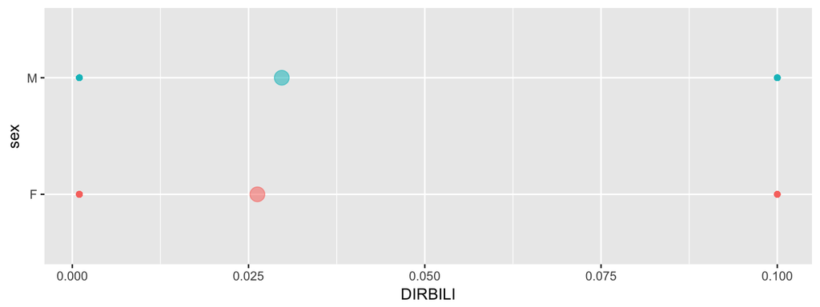

```r
# Filter the data was want and remove NA from variable
dirbiliA <- data %>% filter(period == 2) %>% select(DIRBILI, sex) %>% na.omit

# Calculate the sample means
dirbiliAMean <- aggregate(dirbiliA$DIRBILI  ~ dirbiliA$sex, FUN = 'mean')
colnames(dirbiliAMean) <- c('sex', 'DIRBILI')

# Plot the data
ggplot() +
  geom_point(data = dirbiliA, aes(x = DIRBILI, y = sex, colour = sex, alpha = 0.5), show.legend = FALSE) +
  geom_point(data = dirbiliAMean, aes(x = DIRBILI, y = sex, color = sex, size = 4, alpha = 0.5), show.legend = FALSE)
```

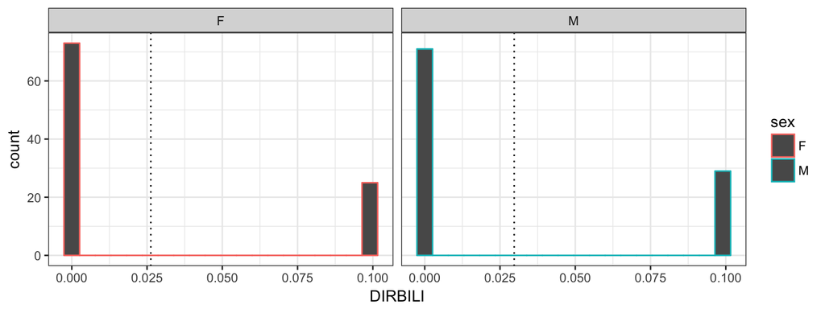

```r
dirbiliA <- ddply(dirbiliA, 'sex', transform, mean = mean(DIRBILI))

ggplot(data = dirbiliA, aes(x = DIRBILI, color = sex)) + geom_histogram(bins = 20) +
  geom_vline(aes(xintercept = mean), linetype = 3) +
  facet_grid(~sex) + theme_bw()
```

This data seems to be discrete, having a value of 0.100 or 0.001 in period 2.

```r
unique(dirbiliA)
```

```
##     DIRBILI sex      mean
## 1     0.100   F 0.0262551
## 2     0.001   F 0.0262551
## 99    0.001   M 0.0297100
## 105   0.100   M 0.0297100
```

```r
# Let's take a look at the means by sex
dirbiliAMean
```

```
##   sex   DIRBILI
## 1   F 0.0262551
## 2   M 0.0297100
```

We will make use of the Chi-Square test to test for independence of `gender` for `DIRBILI`. If gender is independent then the two sexes share the same mean, otherwise they have distinct means.

For the Chi-square test to function in R we need to transform the data into a contingency table following the form:

```r
table(dirbiliA)
```

```
## , , mean = 0.0262551020408163
##
##        sex
## DIRBILI  F  M
##   0.001 73  0
##   0.1   25  0
##
## , , mean = 0.02971
##
##        sex
## DIRBILI  F  M
##   0.001  0 71
##   0.1    0 29
```

We set `correction = FALSE` as correction for continuity adjusts the formula for Pearson’s chi-squared test. It subtracts 0.5 from the difference between each observed value and its expected value in a 2 ? 2 contingency table. This reduces the chi-squared value obtained and thus increases its p-value. This formula is chiefly used when at least one cell of the table has an expected count smaller than 5. As Yates’ correction also tends to overcorrect, and we know that we have significantly more than 5 counts per group we choose not to perform the correction.

The Chi-square test is performed as follows: $\chi^2=\sum_{i = 1}^N\frac{(O_i-E_i)^2}{E_i}$

The df is given by a function of the contingency table: `df = (nrow - 1)(ncol - 1) = (1)(1) = 1`

$H_0: \mu_x\neq\mu_y\space\text{versus}\space H_1:\mu_x=\mu_y$

```r
chisq.test(table(dirbiliA[, 1:2]), correct = FALSE)
```

```
##
##  Pearson's Chi-squared test
##
## data:  table(dirbiliA[, 1:2])
## X-squared = 0.3039, df = 1, p-value = 0.5814
```

Our test returns `p-value = 0.5814` indicating that the two sexes DIRBILI values are not independent and actually share a common mean.

### IMPORTANT REMARK

The chi-square test is intended for categorical variables. Therefore it is unlikely the be applicable in our case where we are working with ordinal and intervaled data. This is why we must resort to the wilcox test.

```r
questionA_wilcox("DIRBILI", 0.05, 1)
```

```
##
##  Wilcoxon rank sum test with continuity correction
##
## data:  (dataNew %>% filter(sex == "M"))[, 2] and (dataNew %>% filter(sex == "F"))[, 2]
## W = 5071, p-value = 0.5835
## alternative hypothesis: true location shift is not equal to 0
```

```r
questionA_wilcox("DIRBILI", 0.05, 1)$p.val
```

```
## [1] 0.5835049
```

The wilcox is a useful approach as it does not assume anything about the distribution or parameters. As our observations consist of only **two** values it is difficult to assume a continuous distribution. Wilcox works around this issue and calculates a p-value = `0.5835049`, similar to that of the chi square test and **rejects the alternative hypothesis**.

##### b. Test for the males if the mean level of DIRBILI is the same for period 1 and period 2.

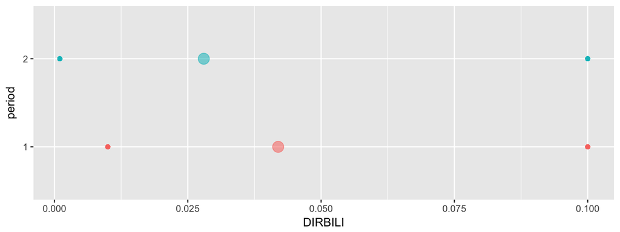

```r
# Filter the data was want and remove NA from variable
dirbiliB <- data %>% select(DIRBILI, period) %>% na.omit
dirbiliB$period <- as.factor(dirbiliB$period)

# Calculate means by period
dirbiliBMean <- aggregate(dirbiliB$DIRBILI ~ dirbiliB$period, FUN = 'mean')
colnames(dirbiliBMean) <- c('period', 'DIRBILI')

# Plot the data
ggplot() +
  geom_point(data = dirbiliB, aes(x = DIRBILI, y = period, colour = period, alpha = 0.5), show.legend = FALSE) +
  geom_point(data = dirbiliBMean, aes(x = DIRBILI, y = period, color = period, size = 4, alpha = 0.5), show.legend = FALSE)
```

We immediately suspect that the two periods do not have independent means. Let us verify our suspicion with a Chi-square test with the same set-up as question a.

```r
table(dirbiliB)
```

```
##        period
## DIRBILI   1   2
##   0.001   0 144
##   0.01  129   0
##   0.1    71  54
```

### IMPORTANT REMARK

The chi-square test is intended for categorical variables. It is **not** applicable in our case where we are working with ordinal and intervaled data with three levels. Although we return a result we cannot use it and must instead resort to the wilcox test.

```r
questionB_wilcox("DIRBILI", 0.05, 1)
```

```
##
##  Wilcoxon rank sum test with continuity correction
##
## data:  (dataNew %>% filter(period == 1))[, 2] and (dataNew %>% filter(period == 2))[, 2]
## W = 7535, p-value = 4.82e-11
## alternative hypothesis: true location shift is not equal to 0
```

```r
questionB_wilcox("DIRBILI", 0.05, 1)$p.val
```

```
## [1] 4.819985e-11
```

The wilcox is a useful approach as it does not assume anything about the distribution or parameters. As our observations consist of only **three** values it is difficult to assume a continuous distribution. Wilcox works around this issue and calculates a low p-value much lower than our 5% cutoff. We find a `p-value = 4.819985e-11` and thus **reject the null hypothesis**. The two sets have distinct means.

##### c. Test for the males if the mean level of DIRBILI for period 2 is the same for the control group and the MON810 group.

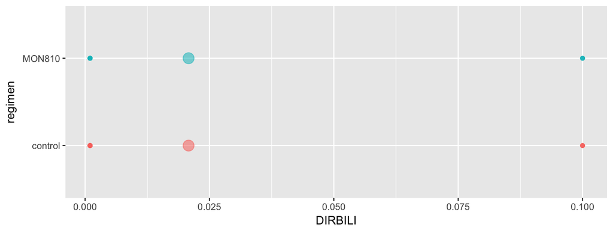

```r
# Filter the data
dirbiliC <- data %>% filter(sex == 'M', period == 2) %>% select(regimen, DIRBILI) %>% filter(regimen %in% c('MON810', 'control')) %>% na.omit

# Calculate the means per regimen
dirbiliCMean <- aggregate(dirbiliC$DIRBILI ~ dirbiliC$regimen, FUN = 'mean')
colnames(dirbiliCMean) <- c('regimen', 'DIRBILI')

# Plot the data
ggplot() +
  geom_point(data = dirbiliC, aes(x = DIRBILI, y = regimen, colour = regimen, alpha = 0.5), show.legend = FALSE) +
  geom_point(data = dirbiliCMean, aes(x = DIRBILI, y = regimen, color = regimen, size = 4, alpha = 0.5), show.legend = FALSE)
```

The plot seems to imply equal means between the `control` and `MON810` regimens.

```r
table(dirbiliC)[1:2,]
```

```
##          DIRBILI
## regimen   0.001 0.1
##   control    16   4
##   MON810     16   4
```

The contingency table shows that the two regiems have exactly the same frequency of each value. We expect a `p-value = 1`. As these are random variables, the true p-value is likely to be very close to 1

```r
chisq.test(table(dirbiliC)[1:2,])
```

```
##
##  Pearson's Chi-squared test
##
## data:  table(dirbiliC)[1:2, ]
## X-squared = 0, df = 1, p-value = 1
```

With a `p-value = 1` we reject the alternative hypothesis. The two regimens `contol` and `MON810` share the same mean.

### IMPORTANT REMARK

The chi-square test is intended for categorical variables. Therefore it is unlikely the be applicable in our case where we are working with ordinal and intervaled data. This is why we must resort to the wilcox test.

###### Wilcox alternative

```r
questionC_wilcox("DIRBILI", 0.05, 1)
```

```
##
##  Wilcoxon rank sum test with continuity correction
##
## data:  (dataNew %>% filter(regimen == "control"))[, 2] and (dataNew %>% filter(regimen == "MON810"))[, 2]
## W = 200, p-value = 1
## alternative hypothesis: true location shift is not equal to 0
```

```r
questionC_wilcox("DIRBILI", 0.05, 1)$p.val
```

```
## [1] 1
```

The wilcox is a useful approach as it does not assume anything about the distribution or parameters. As our observations consist of only two values but their ordinality and interval matter, it is difficult to assume a categorical distribution. Wilcox works around this issue and calculates a p-value equal to the chi square test of 1.

##### d. What is the probability to detect a difference of 1 sd (one standard deviation)

As we are testing two proportions we will need the pwr.2p.test to compute the power.

*i)* with only 10 animals per group?

```r
pwr.2p.test(n = 10, h = 1, alternative = "two.sided", sig.level = 0.05)
```

```
##
##      Difference of proportion power calculation for binomial distribution (arcsine transformation)
##
##               h = 1
##               n = 10
##       sig.level = 0.05
##           power = 0.6087795
##     alternative = two.sided
##
## NOTE: same sample sizes
```

We have a 60.88% power with `n = 10` observations.

*ii)* with 20 animal?

```r
pwr.2p.test(n = 20, h = 1, alternative = "two.sided", sig.level = 0.05)
```

```
##
##      Difference of proportion power calculation for binomial distribution (arcsine transformation)
##
##               h = 1
##               n = 20
##       sig.level = 0.05
##           power = 0.8853791
##     alternative = two.sided
##
## NOTE: same sample sizes
```

We have a 88.54% power with `n = 20` observations.

*iii)* How can we ensure to detect such difference with a probability of 80%?

```r
pwr.2p.test(power = 0.80, h = 1, alternative = "two.sided", sig.level = 0.05)
```

```
##
##      Difference of proportion power calculation for binomial distribution (arcsine transformation)
##
##               h = 1
##               n = 15.69774
##       sig.level = 0.05
##           power = 0.8
##     alternative = two.sided
##
## NOTE: same sample sizes
```

Only by having at least `n = 16` observations can we detect a difference of 1 standard deviation with at least an 80% accuracy.

##### e. Test for the males if the mean levels of calcium for period 2 of the control group and the MON810 are equivalent. The equivalence limits will be defined using the 6 reference groups as

```r
# Filter the data
dirbiliE <- data %>% filter(sex == 'M', period == 2, regimen != 'control', regimen != 'MON810') %>% select(regimen, DIRBILI) %>% na.omit
dirbiliE$regimen <- as.factor(dirbiliE$regimen)

# Calculate the mean of each regiem
dirbiliEMean <- aggregate(dirbiliE$DIRBILI  ~ dirbiliE$regimen, FUN = 'mean')
colnames(dirbiliEMean) <- c('regimen', 'DIRBILI')
dirbiliEMean
```

```
##      regimen DIRBILI
## 1 reference1  0.0307
## 2 reference2  0.0505
## 3 reference3  0.0406
## 4 reference4  0.0307
## 5 reference5  0.0406
## 6 reference6  0.0208
```

*i)* one standard deviation of the 6 reference means

```r
# The size of our confidence interval is given by a deviation from the mean in either direction of:
sd(dirbiliEMean$DIRBILI)
```

```
## [1] 0.01038321
```

```r
# The probability of observing a deviation of this size
pt(q = -sd(dirbiliEMean$DIRBILI), df = dim(dirbiliE)[1]-dim(dirbiliEMean)[1])*2*100
```

```
## [1] 99.17538
```

We find that the probability of observing one standard deviation is `99.18%`.

```r
# Calculate the p-value
test <- tost((dirbiliC %>% filter(regimen == 'control'))[,2], (dirbiliC %>% filter(regimen == 'MON810'))[,2], alpha = 0.05, epsilon = sd(dirbiliEMean$DIRBILI))
test
```

```
##
##  Welch Two Sample TOST
##
## data:  (dirbiliC %>% filter(regimen == "control"))[, 2] and (dirbiliC %>% filter(regimen == "MON810"))[, 2]
## df = 38
## sample estimates:
## mean of x mean of y
##    0.0208    0.0208
##
## Epsilon: 0.01038321
## 95 percent two one-sided confidence interval (TOST interval):
##  -0.02166104  0.02166104
## Null hypothesis of statistical difference is: not rejected
## TOST p-value: 0.2120141
```

```r
# p-value
test$tost.p.value
```

```
## [1] 0.2120141
```

*ii)* two standard deviations of the 6 reference means.

```r
# The probability of observing a deviation of twice this size
pt(q = -2*sd(dirbiliEMean$DIRBILI), df = dim(dirbiliE)[1]-dim(dirbiliEMean)[1])*2*100
```

```
## [1] 98.35085
```

We find that the probability of observing two standard deviations is `98.35%`.

```r
# Calculate the p-value
test <- tost((dirbiliC %>% filter(regimen == 'control'))[,2], (dirbiliC %>% filter(regimen == 'MON810'))[,2], alpha = 0.05, epsilon = 2*sd(dirbiliEMean$DIRBILI))
test
```

```
##
##  Welch Two Sample TOST
##
## data:  (dirbiliC %>% filter(regimen == "control"))[, 2] and (dirbiliC %>% filter(regimen == "MON810"))[, 2]
## df = 38
## sample estimates:
## mean of x mean of y
##    0.0208    0.0208
##
## Epsilon: 0.02076642
## 95 percent two one-sided confidence interval (TOST interval):
##  -0.02166104  0.02166104
## Null hypothesis of statistical difference is: not rejected
## TOST p-value: 0.05714879
```

```r
# p-value
test$tost.p.value
```

```
## [1] 0.05714879
```

##### f. Summarize and comment these results.

# Multiple comparisons

#### **(Q1)**

Redo the three tests of the previous section (questions a., b. and c.) for now comparing the means of all the quantitative variables (see the annex 5 of the ANSES report BIOT2009sa0285Ra.pdf to know the type of each variable).

##### a. mean level for period 2 is the same for males and females.

```r
questionA_ttest <- function(variable, alpha, m){
  # Filter the data was want and remove NA from variable
  dataNew <- data %>% filter(period == 2) %>% select(sex, variable) %>% na.omit

  # Check if the the two groups have at least one observation
  if(dim((dataNew %>% filter(sex == 'M')))[1] > 0 && dim(dataNew %>% filter(sex == 'F'))[1] > 0){
    # F-test
    pVal <- var.test((dataNew %>% filter(sex == 'M'))[,2], (dataNew %>% filter(sex == 'F'))[,2], conf.level = 1 - alpha, alternative = 'two.sided')$p.val

    # Check F-test result
    varEqual <- pVal > alpha

    # Perform the t-test
    return(t.test((dataNew %>% filter(sex == 'M'))[,2], (dataNew %>% filter(sex == 'F'))[,2], conf.level = 1 - alpha/m, var.equal = varEqual)$p.val)
  }
  else{
    return(NA)
  }
}

questionA_wilcox <- function(variable, alpha, m){
  # Filter the data was want and remove NA from variable
  dataNew <- data %>% filter(period == 2) %>% select(sex, variable) %>% na.omit

  # Check if the the two groups have at least one observation
  if(dim((dataNew %>% filter(sex == 'M')))[1] > 0 && dim(dataNew %>% filter(sex == 'F'))[1] > 0){
    # Wilcox p-value
    return(wilcox.test((dataNew %>% filter(sex == 'M'))[,2], (dataNew %>% filter(sex == 'F'))[,2], alternative = 'two.sided', conf.level=1-alpha/m)$p.val)
  }
  else{
    return(NA)
  }
}
```

##### b. test for the males if the mean level is the same for period 1 and period 2.

```r
questionB_ttest <- function(variable, alpha, m){
  # Filter the variable for males in period 1 and 2
  dataNew <- data %>% filter(sex == 'M') %>% select(period, variable) %>% na.omit

  # Check if the the two groups have at least one observation
  if(dim(dataNew %>% filter(period == 2))[1] > 0 && dim(dataNew %>% filter(period == 1))[1] > 0){
    # Calculate F-test's p-value
    pVal <- var.test((dataNew %>% filter(period == 1))[,2], (dataNew %>% filter(period == 2))[,2], conf.level = 1 - alpha, alternative = 'two.sided')$p.value

    # Check if the two periods have equal variances
    varEqual <- pVal > alpha

    # Perform the t-test
    return(t.test((dataNew %>% filter(period == 1))[,2], (dataNew %>% filter(period == 2))[,2], conf.level = 1 - alpha/m, var.equal = varEqual)$p.value)
  }
  else{
    return(NA)
  }
}

questionB_wilcox <- function(variable, alpha, m){
  # Filter the variable for males in period 1 and 2
  dataNew <- data %>% filter(sex == 'M') %>% select(period, variable) %>% na.omit

  # Check if the the two groups have at least one observation
  if(dim(dataNew %>% filter(period == 2))[1] > 0 && dim(dataNew %>% filter(period == 1))[1] > 0){
    # Wilcox p-value
    return(wilcox.test((dataNew %>% filter(period == 1))[,2], (dataNew %>% filter(period == 2))[,2], alternative = 'two.sided', conf.level=1-alpha/m)$p.val)
  }
  else{
    return(NA)
  }
}
```

##### c. test for the males if the mean level for period 2 is the same for the control group and the MON810 group.

```r
questionC_ttest <- function(variable, alpha, m){
  # Filter the data was want and remove NA from variable
  dataNew <- data %>% filter(sex == 'M') %>% filter(period == 2) %>% select(regimen, variable) %>% filter(regimen %in% c('MON810', 'control')) %>% na.omit

  # Check if the the two groups have at least one observation
  if(dim((dataNew %>% filter(regimen == 'control')))[1] > 0 && dim(dataNew %>% filter(regimen == 'MON810'))[1] > 0){
    # Calculate F-test's p-value
    pVal <- var.test((dataNew %>% filter(regimen == 'control'))[,2], (dataNew %>% filter(regimen == 'MON810'))[,2], conf.level = 1 - alpha, alternative = 'two.sided')$p.val

    # Check if the two groups have the same variance
    varEqual <- pVal > alpha

    # Perform the t-test
    return(t.test((dataNew %>% filter(regimen == 'control'))[,2], (dataNew %>% filter(regimen == 'MON810'))[,2], conf.level = 1 - alpha/m, var.equal = varEqual)$p.val)
  }
  else{
    return(NA)
  }
}

questionC_wilcox <- function(variable, alpha, m){
  # Filter the data was want and remove NA from variable
  dataNew <- data %>% filter(sex == 'M') %>% filter(period == 2) %>% select(regimen, variable) %>% filter(regimen %in% c('MON810', 'control')) %>% na.omit

  # Check if the the two groups have at least one observation
  if(dim((dataNew %>% filter(regimen == 'control')))[1] > 0 && dim(dataNew %>% filter(regimen == 'MON810'))[1] > 0){
    # Wilcox p-value
    return(wilcox.test((dataNew %>% filter(regimen == 'control'))[,2], (dataNew %>% filter(regimen == 'MON810'))[,2], alternative = 'two.sided', conf.level=1-alpha/m)$p.val)
  }
  else{
    return(NA)
  }
}
```

##### Merg data

Store the results (i.e. all the p-values) in a dataframe with one variable per row and four columns (name of the variable + three p-values).

Non-quantitative variables: BILI, PROT, GLUCOSE, BLOOD, KETONE, UROBILI, GAMMAGT

```r
variable <- data  %>% select(-GLUCOSE, -BLOOD, -BILI, -PROT ,-KETONE, -UROBILI, -GAMMAGT, -id, -X, -regimen, -sex, -period) %>% colnames()

wilcox <- data.frame()
ttest <- data.frame()
for (i in 1:length(variable)){
  # Wilcox results
  wilcox <- rbind(wilcox, cbind(variable[i], questionA_wilcox(variable[i], 0.05, 1), questionB_wilcox(variable[i], 0.05, 1), questionC_wilcox(variable[i], 0.05, 1)))
  # t-test results
  ttest <- rbind(ttest, cbind(variable[i], questionA_ttest(variable[i], 0.05, 1), questionB_ttest(variable[i], 0.05, 1), questionC_ttest(variable[i], 0.05, 1)))
}

colnames(wilcox) <- c('variable', 'a', 'b', 'c')
colnames(ttest) <- c('variable', 'a', 'b', 'c')
```

Lets see which t-tests have a p-value below 0.05

```r
ttest$variable <- as.character(ttest$variable)
ttest$a <- as.numeric(paste(ttest$a))
ttest$b <- as.numeric(paste(ttest$b))
ttest$c <- as.numeric(paste(ttest$c))
ttest05 <- as.data.frame(cbind(ttest$variable, ttest[,2:4] < 0.05))
ttest05
```

```
##                    V1     a     b     c
## 1             ALBUMIN  TRUE  TRUE FALSE
## 2           ALKPHOSPH  TRUE  TRUE FALSE
## 3             SGPTALT  TRUE FALSE FALSE
## 4             SGOTAST  TRUE  TRUE FALSE
## 5             TOTBILI FALSE  TRUE FALSE
## 6                 BUN  TRUE  TRUE FALSE
## 7       CALCIUM.blood  TRUE  TRUE FALSE
## 8         CREAT.blood  TRUE  TRUE FALSE
## 9            Glycemia  TRUE  TRUE FALSE
## 10       PHOSPH.blood  TRUE  TRUE FALSE
## 11            TOTPROT  TRUE  TRUE FALSE
## 12            DIRBILI FALSE FALSE FALSE
## 13        SODIUM.Sang FALSE  TRUE FALSE
## 14     POTASSIUM.Sang  TRUE  TRUE FALSE
```

[output cut: 46 more lines]

Lets see which wilcox-tests have a p-value below 0.05

```r
wilcox$variable <- as.character(wilcox$variable)
wilcox$a <- as.numeric(paste(wilcox$a))
wilcox$b <- as.numeric(paste(wilcox$b))
wilcox$c <- as.numeric(paste(wilcox$c))
wilcox05 <- as.data.frame(cbind(variable, wilcox[,2:4] < 0.05))
wilcox05
```

```
##              variable     a     b     c
## 1             ALBUMIN  TRUE  TRUE FALSE
## 2           ALKPHOSPH  TRUE  TRUE FALSE
## 3             SGPTALT FALSE  TRUE FALSE
## 4             SGOTAST  TRUE  TRUE FALSE
## 5             TOTBILI  TRUE  TRUE FALSE
## 6                 BUN  TRUE  TRUE FALSE
## 7       CALCIUM.blood  TRUE  TRUE FALSE
## 8         CREAT.blood  TRUE  TRUE FALSE
## 9            Glycemia  TRUE  TRUE FALSE
## 10       PHOSPH.blood  TRUE  TRUE FALSE
## 11            TOTPROT  TRUE  TRUE FALSE
## 12            DIRBILI FALSE  TRUE FALSE
## 13        SODIUM.Sang FALSE  TRUE FALSE
## 14     POTASSIUM.Sang  TRUE  TRUE FALSE
```

[output cut: 46 more lines]

```r
as.data.frame(cbind(variable, (ttest05 == wilcox05)[,2:4]))
```

```
##              variable     a     b    c
## 1             ALBUMIN  TRUE  TRUE TRUE
## 2           ALKPHOSPH  TRUE  TRUE TRUE
## 3             SGPTALT FALSE FALSE TRUE
## 4             SGOTAST  TRUE  TRUE TRUE
## 5             TOTBILI FALSE  TRUE TRUE
## 6                 BUN  TRUE  TRUE TRUE
## 7       CALCIUM.blood  TRUE  TRUE TRUE
## 8         CREAT.blood  TRUE  TRUE TRUE
## 9            Glycemia  TRUE  TRUE TRUE
## 10       PHOSPH.blood  TRUE  TRUE TRUE
## 11            TOTPROT  TRUE  TRUE TRUE
## 12            DIRBILI  TRUE FALSE TRUE
## 13        SODIUM.Sang  TRUE  TRUE TRUE
## 14     POTASSIUM.Sang  TRUE  TRUE TRUE
```

[output cut: 46 more lines]

#### **(Q2)**

For each of the three tests, adjust the p-values using the Bonferroni and the Benjamini-Hochberg corrections. How can we interpret these results?

##### Bonferroni correction

Bonferroni’s correction derives from that fact that the probability of identifying at least one significant result due to chance increases as more hypotheses are tested. Therefore we divide each alpha by the number of tests calculated per question. The amounts differ by question due to the different amounts of NAs in the results from trying to test sets that are uncomparable due to nonexistant observations.

```r
wilcoxBonferroni <- as.data.frame(variable)
wilcoxBonferroni$`a Bonferroni` <- p.adjust(wilcox$a, method = "bonferroni", n = 60-sum(is.na(wilcox$a)))
wilcoxBonferroni$`b Bonferroni` <- p.adjust(wilcox$b, method = "bonferroni", n = 60-sum(is.na(wilcox$b)))
wilcoxBonferroni$`c Bonferroni` <- p.adjust(wilcox$c, method = "bonferroni", n = 60-sum(is.na(wilcox$c)))

ttestBonferroni <- as.data.frame(variable)
ttestBonferroni$`a Bonferroni` <- p.adjust(ttest$a, method = "bonferroni", n = 60-sum(is.na(ttest$a)))
ttestBonferroni$`b Bonferroni` <- p.adjust(ttest$b, method = "bonferroni", n = 60-sum(is.na(ttest$b)))
ttestBonferroni$`c Bonferroni` <- p.adjust(ttest$c, method = "bonferroni", n = 60-sum(is.na(ttest$c)))
```

Let us see which p-values are below `0.05`.

```r
wilcoxBonferroni05 <- as.data.frame(cbind(variable, wilcoxBonferroni[,2:4] < 0.05))
wilcoxBonferroni05
```

```
##              variable a Bonferroni b Bonferroni c Bonferroni
## 1             ALBUMIN         TRUE         TRUE        FALSE
## 2           ALKPHOSPH         TRUE         TRUE        FALSE
## 3             SGPTALT        FALSE         TRUE        FALSE
## 4             SGOTAST        FALSE         TRUE        FALSE
## 5             TOTBILI         TRUE         TRUE        FALSE
## 6                 BUN         TRUE         TRUE        FALSE
## 7       CALCIUM.blood         TRUE         TRUE        FALSE
## 8         CREAT.blood         TRUE         TRUE        FALSE
## 9            Glycemia         TRUE         TRUE        FALSE
## 10       PHOSPH.blood        FALSE         TRUE        FALSE
## 11            TOTPROT         TRUE         TRUE        FALSE
## 12            DIRBILI        FALSE         TRUE        FALSE
## 13        SODIUM.Sang        FALSE         TRUE        FALSE
## 14     POTASSIUM.Sang         TRUE         TRUE        FALSE
```

[output cut: 46 more lines]

##### Benjamini-Hochberg correction

```r
wilcoxBH <- as.data.frame(variable)
wilcoxBH$`a Ben-Hoch` <- p.adjust(wilcox$a, method = "BH", n = 60-sum(is.na(wilcox$a)))
wilcoxBH$`b Ben-Hoch` <- p.adjust(wilcox$b, method = "BH", n = 60-sum(is.na(wilcox$b)))
wilcoxBH$`c Ben-Hoch` <- p.adjust(wilcox$c, method = "BH", n = 60-sum(is.na(wilcox$c)))

ttestBH <- as.data.frame(variable)
ttestBH$`a Ben-Hoch` <- p.adjust(ttest$a, method = "BH", n = 60-sum(is.na(ttest$a)))
ttestBH$`b Ben-Hoch` <- p.adjust(ttest$b, method = "BH", n = 60-sum(is.na(ttest$b)))
ttestBH$`c Ben-Hoch` <- p.adjust(ttest$c, method = "BH", n = 60-sum(is.na(ttest$c)))
```

```r
wilcoxBH05 <- as.data.frame(cbind(variable, wilcoxBH[,2:4] < 0.05))
wilcoxBH05
```

```
##              variable a Ben-Hoch b Ben-Hoch c Ben-Hoch
## 1             ALBUMIN       TRUE       TRUE      FALSE
## 2           ALKPHOSPH       TRUE       TRUE      FALSE
## 3             SGPTALT      FALSE       TRUE      FALSE
## 4             SGOTAST       TRUE       TRUE      FALSE
## 5             TOTBILI       TRUE       TRUE      FALSE
## 6                 BUN       TRUE       TRUE      FALSE
## 7       CALCIUM.blood       TRUE       TRUE      FALSE
## 8         CREAT.blood       TRUE       TRUE      FALSE
## 9            Glycemia       TRUE       TRUE      FALSE
## 10       PHOSPH.blood       TRUE       TRUE      FALSE
## 11            TOTPROT       TRUE       TRUE      FALSE
## 12            DIRBILI      FALSE       TRUE      FALSE
## 13        SODIUM.Sang      FALSE       TRUE      FALSE
## 14     POTASSIUM.Sang       TRUE       TRUE      FALSE
```

[output cut: 46 more lines]

##### Bonferroni vs Benjamini & Hochberg

Let us check where the two corrections agree at a 5% cutoff.

```r
bonBH <- as.data.frame(cbind(variable, wilcoxBonferroni05[,2:4] == wilcoxBH05[,2:4]))
colnames(bonBH) <- c('variable', 'a comparison', 'b comparison', 'c comparison')
head(bonBH)
```

```
##    variable a comparison b comparison c comparison
## 1   ALBUMIN         TRUE         TRUE         TRUE
## 2 ALKPHOSPH         TRUE         TRUE         TRUE
## 3   SGPTALT         TRUE         TRUE         TRUE
## 4   SGOTAST        FALSE         TRUE         TRUE
## 5   TOTBILI         TRUE         TRUE         TRUE
## 6       BUN         TRUE         TRUE         TRUE
```

The table above shows where the two correction methods resulted in conflicting results at a 5% level.

```r
# How many conflicts in question A?
length(which(factor(bonBH$`a comparison`) == FALSE))
```

```
## [1] 7
```

```r
# B?
length(which(factor(bonBH$`b comparison`) == FALSE))
```

```
## [1] 7
```

```r
# C?
length(which(factor(bonBH$`c comparison`) == FALSE))
```

```
## [1] 0
```

```r
# A: Proportion of conflicts to the number of tests
length(which(factor(bonBH$`a comparison`) == FALSE)) / (60 - sum(is.na(bonBH$`a comparison`)))*100
```

```
## [1] 12.06897
```

```r
# B: Proportion of conflicts to the number of tests
length(which(factor(bonBH$`b comparison`) == FALSE)) / (60 - sum(is.na(bonBH$`b comparison`)))*100
```

```
## [1] 14.28571
```

```r
# C: Proportion of conflicts to the number of tests
length(which(factor(bonBH$`c comparison`) == FALSE)) / (60 - sum(is.na(bonBH$`c comparison`)))*100
```

```
## [1] 0
```

They differ on question A on 7 occasions around 12% of the tests. They differ on question B on 7 occasions around 14% of the tests. They do not differ on question C.

###### How can we interpret these results?

The reason we calculate the corrected p-values is because we are doing so many tests, it becomes more likely that a result is an outlier, therefore we adjust the p-value by a function of the number of tests. The new p-value then tells us whether to reject the null or alternative hypothesis from the set of tests when it is below a set threshold such as 5%.